# Data: Web Scraping

Monday · Session 3

Diego A. Guerrero

GDP Growth Nowcasting Workshop | Trinidad and Tobago

## Learning objectives

- Retrieve data from **public APIs** (FRED)
- Make a **plain web request** and read what the server sends back
- Read tables straight from **central-bank web pages** (CBTT Data Centre)
- Save every source as one tidy CSV in `raw/`, ready for the build

# Accessing an API

Some data providers build an address for programs, not for people

## What is an API?

An **API** (Application Programming Interface) is an address a data provider builds for programs: you ask for a series and get **data** back (JSON or CSV), not a web page.

An **API key** is a personal code that tells the provider who is asking. It limits requests and enforces the page rules.

A FRED API call is a URL, edited according to the parameters listed in the API documentation:

```
https://api.stlouisfed.org/fred/series/observations?series_id=<ID HERE>&api_key=<KEY HERE>&file_type=<FORMAT HERE>
```

| Part | Meaning |
| --- | --- |
| `https://api.stlouisfed.org/fred/series/observations` | the service: observations of one series |
| `series_id=<ID HERE>` | which series (e.g. `DCOILBRENTEU`, Brent oil price) |
| `api_key=<KEY HERE>` | who is asking |
| `file_type=<FORMAT HERE>` | the format of the answer (e.g. `json`) |

## FRED API Example

**FRED package**

```python
from fredapi import Fred

fred = Fred(api_key=key)
brent = fred.get_series("DCOILBRENTEU")
```

Needs `pip install fredapi`.

**FRED `requests`**

```python
import requests, pandas as pd

url = ("https://api.stlouisfed.org/fred/series/observations"
       f"?series_id=DCOILBRENTEU&api_key={key}&file_type=json")
obs = requests.get(url, timeout=60).json()["observations"]
brent = pd.DataFrame(obs)[["date", "value"]]
```

The same URL as the previous slide.

# Web pages without an API

A web page is made for people to read, not for programs

## A simple request

Without an API, `requests.get` returns whatever the server sends:

```python
import requests, pandas as pd

r = requests.get("https://www.central-bank.org.tt", timeout=60)
print(r.status_code)                  # 200 = OK, 403 = blocked, 404 = not found
print(r.headers["Content-Type"])      # text/html: a web page, not data
print(r.text[:300])                   # the raw HTML

# When the address is a FILE, pandas reads it directly
brent = pd.read_csv("https://fred.stlouisfed.org/graph/fredgraph.csv?id=DCOILBRENTEU")
```

A web page is text. The numbers are inside it, wrapped in HTML tags.

## The CBTT Data Centre

```
https://www.central-bank.org.tt/data-center-block/?title=<table-name>&id=<n>
```

| Table | `id` |
| --- | --- |
| Consumer price index, monthly | 36 |
| Fiscal revenue, monthly | 90 |
| Fiscal expenditure, monthly | 94 |
| Fiscal financing, monthly | 102 |

Standardized format: change the URL, keep the code.

## Web Page: HTML

**What the browser shows**

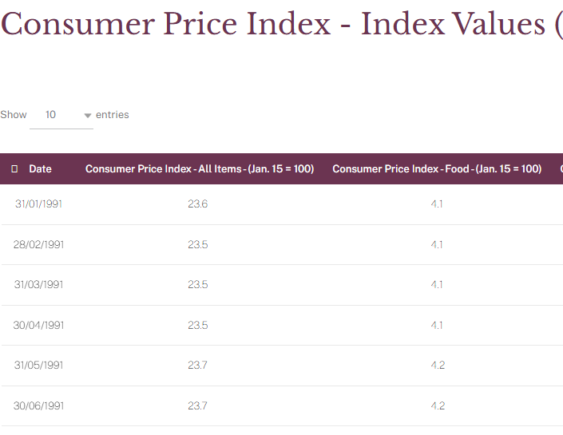

**The HTML code behind**

```html
<table id="table_1" class="scroll responsive display nowrap data-t data-t wpDataTable wpDataTableID-36 dataTable dtfc-has-left" style="" data-described-by="table_1_desc" data-wpdatatable_id="36" aria-describedby="table_1_info">
  <!-- Table header -->
  <thead>
    <tr>
      <th data-class="expand" class="wdtheader sort expand column-date sorting dtfc-fixed-left sorting_asc" style="left: 0px; position: sticky;" tabindex="0" aria-controls="table_1" rowspan="1" colspan="1" aria-label=" Dateundefined" aria-sort="ascending"> Date</th>
      <th class="wdtheader column-consumer-price-index---all-items---jan-15--100 sorting_disabled" style="" rowspan="1" colspan="1" aria-label=" Consumer Price Index - All Items - (Jan. 15 = 100)"> Consumer Price Index - All Items - (Jan. 15 = 100)</th>
      <th class="wdtheader column-consumer-price-index---food---jan-15--100 sorting_disabled" style="" rowspan="1" colspan="1" aria-label=" Consumer Price Index - Food - (Jan. 15 = 100)"> Consumer Price Index - Food - (Jan. 15 = 100)</th>
      <th class="wdtheader column-consumer-price-index---core-jan-15--100 sorting_disabled" style="" rowspan="1" colspan="1" aria-label=" Consumer Price Index - Core (Jan. 15 = 100)"> Consumer Price Index - Core (Jan. 15 = 100)</th>
      <th class="wdtheader column-consumer-price-index---bread-and-cereals-jan-15--100 sorting_disabled" style="" rowspan="1" colspan="1" aria-label=" Consumer Price Index - Bread and Cereals (Jan. 15 = 100)"> Consumer Price Index - Bread and Cereals (Jan. 15 = 100)</th>
      <th class="wdtheader column-consumer-price-index---meat-jan-15--100 sorting_disabled" style="" rowspan="1" colspan="1" aria-label=" Consumer Price Index - Meat (Jan. 15 = 100)"> Consumer Price Index - Meat (Jan. 15 = 100)</th>
      <th class="wdtheader column-consumer-price-index---fish-jan-15--100 sorting_disabled" style="" rowspan="1" colspan="1" aria-label=" Consumer Price Index - Fish (Jan. 15 = 100)"> Consumer Price Index - Fish (Jan. 15 = 100)</th>
      <th class="wdtheader column-consumer-price-index---milk-cheese-and-eggs-jan-15--100 sorting_disabled" style="" rowspan="1" colspan="1" aria-label=" Consumer Price Index - Milk, Cheese and Eggs (Jan. 15 = 100)"> Consumer Price Index - Milk, Cheese and Eggs (Jan. 15 = 100)</th>
      <th class="wdtheader column-consumer-price-index---oils-and-fats-jan-15--100 sorting_disabled" style="" rowspan="1" colspan="1" aria-label=" Consumer Price Index - Oils and Fats (Jan. 15 = 100)"> Consumer Price Index - Oils and Fats (Jan. 15 = 100)</th>
      <th class="wdtheader column-consumer-price-index---fruits-jan-15--100 sorting_disabled" style="" rowspan="1" colspan="1" aria-label=" Consumer Price Index - Fruits (Jan. 15 = 100)"> Consumer Price Index - Fruits (Jan. 15 = 100)</th>
      <th class="wdtheader column-consumer-price-index---vegetables-jan-15--100 sorting_disabled" style="" rowspan="1" colspan="1" aria-label=" Consumer Price Index - Vegetables (Jan. 15 = 100)"> Consumer Price Index - Vegetables (Jan. 15 = 100)</th>
      <th class="wdtheader column-consumer-price-index---non-alcoholic-drinks-jan-15--100 sorting_disabled" style="" rowspan="1" colspan="1" aria-label=" Consumer Price Index - Non-Alcoholic Drinks (Jan. 15 = 100)"> Consumer Price Index - Non-Alcoholic Drinks (Jan. 15 = 100)</th>
      <th class="wdtheader column-consumer-price-index---alcoholic-beverages-and-tobacco-jan-15--100 sorting_disabled" style="" rowspan="1" colspan="1" aria-label=" Consumer Price Index - Alcoholic Beverages and Tobacco (Jan. 15 = 100)"> Consumer Price Index - Alcoholic Beverages and Tobacco (Jan. 15 = 100)</th>
      <th class="wdtheader column-consumer-price-index---clothing--footwear---jan-15--100 sorting_disabled" style="" rowspan="1" colspan="1" aria-label=" Consumer Price Index - Clothing &amp;amp; Footwear - (Jan. 15 = 100)"> Consumer Price Index - Clothing &amp; Footwear - (Jan. 15 = 100)</th>
      <th class="wdtheader column-consumer-price-index---communication-jan-15--100 sorting_disabled" style="" rowspan="1" colspan="1" aria-label=" Consumer Price Index - Communication (Jan. 15 = 100)"> Consumer Price Index - Communication (Jan. 15 = 100)</th>
      <th class="wdtheader column-consumer-price-index---education-jan-15--100 sorting_disabled" style="" rowspan="1" colspan="1" aria-label=" Consumer Price Index - Education (Jan. 15 = 100)"> Consumer Price Index - Education (Jan. 15 = 100)</th>
      <th class="wdtheader column-consumer-price-index---health-jan-15--100 sorting_disabled" style="" rowspan="1" colspan="1" aria-label=" Consumer Price Index - Health (Jan. 15 = 100)"> Consumer Price Index - Health (Jan. 15 = 100)</th>
      <th class="wdtheader column-consumer-price-index---housing---jan-15--100 sorting_disabled" style="" rowspan="1" colspan="1" aria-label=" Consumer Price Index - Housing - (Jan. 15 = 100)"> Consumer Price Index - Housing - (Jan. 15 = 100)</th>
      <th class="wdtheader column-consumer-price-index---rent---jan-15--100 sorting_disabled" style="" rowspan="1" colspan="1" aria-label=" Consumer Price Index - Rent - (Jan. 15 = 100)"> Consumer Price Index - Rent - (Jan. 15 = 100)</th>
      <th class="wdtheader column-consumer-price-index---imputed-rent---jan-15--100 sorting_disabled" style="" rowspan="1" colspan="1" aria-label=" Consumer Price Index - Imputed Rent - (Jan. 15 = 100)"> Consumer Price Index - Imputed Rent - (Jan. 15 = 100)</th>
      <th class="wdtheader column-consumer-price-index---water-electricity-gas-and-other-fuels---jan-15--100 sorting_disabled" style="" rowspan="1" colspan="1" aria-label=" Consumer Price Index - Water, Electricity, Gas and Other Fuels - (Jan. 15 = 100)"> Consumer Price Index - Water, Electricity, Gas and Other Fuels - (Jan. 15 = 100)</th>
      <th class="wdtheader column-consumer-price-index---transportation-jan-15--100 sorting_disabled" style="" rowspan="1" colspan="1" aria-label=" Consumer Price Index - Transportation (Jan. 15 = 100)"> Consumer Price Index - Transportation (Jan. 15 = 100)</th>
      <th class="wdtheader column-consumer-price-index---furnishings-household-equipment-and-routine-maintenance-of-the-house-jan-15--100 sorting_disabled" style="" rowspan="1" colspan="1" aria-label=" Consumer Price Index - Furnishings, Household Equipment and Routine Maintenance of the House (Jan. 15 = 100)"> Consumer Price Index - Furnishings, Household Equipment and Routine Maintenance of the House (Jan. 15 = 100)</th>
      <th class="wdtheader column-consumer-price-index---recreation-and-culture-jan-15--100 sorting_disabled" style="" rowspan="1" colspan="1" aria-label=" Consumer Price Index - Recreation and Culture (Jan. 15 = 100)"> Consumer Price Index - Recreation and Culture (Jan. 15 = 100)</th>
      <th class="wdtheader column-consumer-price-index---hotels-cafes-and-restaurants-jan-15--100 sorting_disabled" style="" rowspan="1" colspan="1" aria-label=" Consumer Price Index - Hotels, Cafes and Restaurants (Jan. 15 = 100)"> Consumer Price Index - Hotels, Cafes and Restaurants (Jan. 15 = 100)</th>
      <th class="wdtheader column-consumer-price-index---miscellaneous-goods-and-services-jan-15--100 sorting_disabled" style="" rowspan="1" colspan="1" aria-label=" Consumer Price Index - Miscellaneous Goods and Services (Jan. 15 = 100)"> Consumer Price Index - Miscellaneous Goods and Services (Jan. 15 = 100)</th>
      <th class="wdtheader column-consumer-price-index---all-items---jan-15--100---tobago sorting_disabled" style="" rowspan="1" colspan="1" aria-label=" Consumer Price Index - All Items - (Jan. 15 = 100) - Tobago"> Consumer Price Index - All Items - (Jan. 15 = 100) - Tobago</th>
      <th class="wdtheader column-consumer-price-index---food---jan-15--100---tobago sorting_disabled" style="" rowspan="1" colspan="1" aria-label=" Consumer Price Index - Food - (Jan. 15 = 100) - Tobago"> Consumer Price Index - Food - (Jan. 15 = 100) - Tobago</th>
      <th class="wdtheader column-consumer-price-index---core---jan-15--100---tobago sorting_disabled" style="" rowspan="1" colspan="1" aria-label=" Consumer Price Index - Core - (Jan. 15 = 100) - Tobago"> Consumer Price Index - Core - (Jan. 15 = 100) - Tobago</th>
    </tr>
  </thead>
  <!-- /Table header -->
  <!-- Table body -->
  <tbody>
  <!-- Table body -->
  <!-- /Table body -->
    <tr id="table_36_row_429" data-row-index="429" class="odd">
      <td style="left: 0px; position: sticky;" class="expand column-date dtfc-fixed-left sorting_1"><span class="responsiveExpander"></span>31/01/1991</td>
      <td style="" data-cbtt-dp="1" class="cbtt-dp-cell column-consumer-price-index---all-items---jan-15--100"><span class="cbtt-dp cbtt-dp-int">23</span><span class="cbtt-dp cbtt-dp-dec">.6</span></td>
      <td style="" data-cbtt-dp="1" class="cbtt-dp-cell column-consumer-price-index---food---jan-15--100"><span class="cbtt-dp cbtt-dp-int">4</span><span class="cbtt-dp cbtt-dp-dec">.1</span></td>
      <td style="" data-cbtt-dp="1" class="cbtt-dp-cell column-consumer-price-index---core-jan-15--100"><span class="cbtt-dp cbtt-dp-int">56</span><span class="cbtt-dp cbtt-dp-dec">.8</span></td>
      <td style="" class=" column-consumer-price-index---bread-and-cereals-jan-15--100">n.d.</td>
      <td style="" class=" column-consumer-price-index---meat-jan-15--100">n.d.</td>
      <td style="" class=" column-consumer-price-index---fish-jan-15--100">n.d.</td>
      <td style="" class=" column-consumer-price-index---milk-cheese-and-eggs-jan-15--100">n.d.</td>
      <td style="" class=" column-consumer-price-index---oils-and-fats-jan-15--100">n.d.</td>
      <td style="" class=" column-consumer-price-index---fruits-jan-15--100">n.d.</td>
      <td style="" class=" column-consumer-price-index---vegetables-jan-15--100">n.d.</td>
      <td style="" class=" column-consumer-price-index---non-alcoholic-drinks-jan-15--100">n.d.</td>
      <td style="" data-cbtt-dp="1" class="cbtt-dp-cell column-consumer-price-index---alcoholic-beverages-and-tobacco-jan-15--100"><span class="cbtt-dp cbtt-dp-int">25</span><span class="cbtt-dp cbtt-dp-dec">.0</span></td>
      <td style="" data-cbtt-dp="1" class="cbtt-dp-cell column-consumer-price-index---clothing--footwear---jan-15--100"><span class="cbtt-dp cbtt-dp-int">111</span><span class="cbtt-dp cbtt-dp-dec">.5</span></td>
      <td style="" class=" column-consumer-price-index---communication-jan-15--100">n.d.</td>
      <td style="" class=" column-consumer-price-index---education-jan-15--100">n.d.</td>
      <td style="" class=" column-consumer-price-index---health-jan-15--100">n.d.</td>
      <td style="" data-cbtt-dp="1" class="cbtt-dp-cell column-consumer-price-index---housing---jan-15--100"><span class="cbtt-dp cbtt-dp-int">65</span><span class="cbtt-dp cbtt-dp-dec">.0</span></td>
      <td style="" data-cbtt-dp="1" class="cbtt-dp-cell column-consumer-price-index---rent---jan-15--100"><span class="cbtt-dp cbtt-dp-int">50</span><span class="cbtt-dp cbtt-dp-dec">.3</span></td>
      <td style="" data-cbtt-dp="1" class="cbtt-dp-cell column-consumer-price-index---imputed-rent---jan-15--100"><span class="cbtt-dp cbtt-dp-int">59</span><span class="cbtt-dp cbtt-dp-dec">.0</span></td>
      <td style="" data-cbtt-dp="1" class="cbtt-dp-cell column-consumer-price-index---water-electricity-gas-and-other-fuels---jan-15--100"><span class="cbtt-dp cbtt-dp-int">66</span><span class="cbtt-dp cbtt-dp-dec">.9</span></td>
      <td style="" data-cbtt-dp="1" class="cbtt-dp-cell column-consumer-price-index---transportation-jan-15--100"><span class="cbtt-dp cbtt-dp-int">46</span><span class="cbtt-dp cbtt-dp-dec">.4</span></td>
      <td style="" data-cbtt-dp="1" class="cbtt-dp-cell column-consumer-price-index---furnishings-household-equipment-and-routine-maintenance-of-the-house-jan-15--100"><span class="cbtt-dp cbtt-dp-int">74</span><span class="cbtt-dp cbtt-dp-dec">.6</span></td>
      <td style="" data-cbtt-dp="1" class="cbtt-dp-cell column-consumer-price-index---recreation-and-culture-jan-15--100"><span class="cbtt-dp cbtt-dp-int">44</span><span class="cbtt-dp cbtt-dp-dec">.1</span></td>
```

```html
      <td style="" data-cbtt-dp="1" class="cbtt-dp-cell column-consumer-price-index---hotels-cafes-and-restaurants-jan-15--100"><span class="cbtt-dp cbtt-dp-int">38</span><span class="cbtt-dp cbtt-dp-dec">.4</span></td>
      <td style="" data-cbtt-dp="1" class="cbtt-dp-cell column-consumer-price-index---miscellaneous-goods-and-services-jan-15--100"><span class="cbtt-dp cbtt-dp-int">43</span><span class="cbtt-dp cbtt-dp-dec">.8</span></td>
      <td style="" class=" column-consumer-price-index---all-items---jan-15--100---tobago">n.d.</td>
      <td style="" class=" column-consumer-price-index---food---jan-15--100---tobago">n.d.</td>
      <td style="" class=" column-consumer-price-index---core---jan-15--100---tobago">n.d.</td>
    </tr>
```

## The recipe: request → table → DataFrame

```python
import requests, pandas as pd
from bs4 import BeautifulSoup

hdr = {"User-Agent": "Mozilla/5.0"}          # look like a browser
url = ("https://www.central-bank.org.tt/data-center-block/"
       "?title=consumer-price-index-index-values-monthly&id=36")
r = requests.get(url, headers=hdr, timeout=60)

r.raise_for_status()                          # stop on 403 / 404 / 500
soup  = BeautifulSoup(r.text, "html.parser")
table = soup.select_one("table#table_1")      # the data table on every page

cols = [th.get_text(strip=True) for th in table.select("thead th")]
rows = [[td.get_text(strip=True) for td in tr.select("td")]
        for tr in table.select("tbody tr")]
df = pd.DataFrame([r for r in rows if r], columns=cols)

df["date"] = pd.to_datetime(df["Date"])
df = df.set_index("date").drop(columns="Date").apply(pd.to_numeric, errors="coerce")
df.to_csv("../raw/cbtt_cpi.csv")
```

## Three ways to get a series

| Way | When | T&T example |
| --- | --- | --- |
| **API** | the provider offers one | FRED (oil, US activity), Eurostat |
| **HTML table** | the numbers are on the page | CBTT Data Centre: CPI, fiscal, credit, energy output |
| **File link** | the page links to `.xlsx` / `.csv` | EIA Brent, US Census trade, StatCan |

## When the server does not cooperate

### Symptoms

- `403 Forbidden` → the site blocks scripts: add browser headers
- `SSLError` → certificate problems: `verify=False` (only for public data)
- the page loads but the table is empty → it is filled by JavaScript

### What to do

- add a `timeout=` and a retry; never loop without a pause
- **merge onto the existing CSV**, so a bad day never deletes history